# Vignette 2 (IMDb Movie data)

Zhang ZhenYuan zzha315

## The Data

The [IMdB](https://www.imdb.com) is one of the most famous and popular film review website around the world and it has a large amount of reliable data related to movie. In this program, we’ll mainly focus on scraping for the features for one hundred most popular feature movies in 2018 from IMdB and conduct some data analysis and data visualization those features. And those data is recorded in the following web page (https://www.imdb.com/search/title/?count=100&release_date=2018,2018&title_type=feature).

## Web scraping

Firstly,we’ll use the R package called `rvest` wriiten by H. Wickham, it is a very useful and powerful wrappers around the “xml2” and “httr” packages to make it easy to download and then manipulate HTML and XML. After loading this package into R, we read in the html webpage from its URL and save its content in the variable called ‘webpage’ .

```r
if(!require("rvest"))  {install.packages("rvest")}
library("rvest")

url <- 'https://www.imdb.com/search/title/?count=100&release_date=2018,2018&title_type=feature'
webpage <- read_html(url)
```

Here is a screenshot of the webpage:

[figure not shown]

Screenshot for the web Page after openning the attribute table

Take a feature film as an example,we can see that a movie usually contains the following features:

- **Rank**, the rank of the top listed films from 1 to 100 ,
- **Title**, the name of the film,
- **Runtime**, the time length of the film,
- **Genre**, the genre(type) of the film,
- **Votes**, how many people voted for the film,
- **Description**, a brief introduction and description to the film,
- **Rating**, the rating of the film,
- **Gross_Earning_in_Mil**, the box office revenue of the film,the unit is million,
- **Metascore**, the metascore of this film on IMdB,
- **Director**, the main director of the film,only show the first one, and
- **Actor**, the main actor of the film,only show the first one.

[figure not shown]

Screenshot for the web Page after openning the attribute table

Firstly, let’s scrape the Rank.We still click the F12 key to view the source code of the web page, and use the selector tool in the chorome browser to get the specific CSS selector containing the Rank. Now we can copy the CSS selector corresponding to Rank: `.text-primary` We use `html_nodes()`function to more easily extract the pieces we want out of HTML documents by using XPath or CSS selectors.Then we use `html_text()` function to extract the text content from the that piece. The format of original result is a number with a full point: ‘1. 2. 3. …..’, we can convert them to numeric format like ‘1 2 3’ by using `as.numeric()` function.

[figure not shown]

Screenshot for the web Page after openning the attribute table

```r
#rank_data
rank_data_html <- html_nodes(webpage,'.text-primary')
rank_data <- html_text(rank_data_html)
#Or combine them together: html_nodes(webpage,'.text-primary') %>% html_text()
head(rank_data)
```

```
## [1] "1." "2." "3." "4." "5." "6."
```

```r
rank_data<-as.numeric(rank_data)
#check the output
head(rank_data)
```

```
## [1] 1 2 3 4 5 6
```

Then we use the same method to get the titles for the top 100 feature film. And the css selector returns ‘.lister-item-header a’ for title, we should change that part in `html_nodes()` function.

```r
#title_data
title_data_html <- html_nodes(webpage,'.lister-item-header a')
title_data <- html_text(title_data_html)
head(title_data)
```

```
## [1] "A Quiet Place"                     "Crazy Rich Asians"
## [3] "The Nun"                           "Avengers: Infinity War"
## [5] "Bad Times at the El Royale"        "Spider-Man: Into the Spider-Verse"
```

Similarly, for runtime data, we can get the original result like ‘120 min’and its format is composed of numbers and units(min). We only keep the numeric part for later data analysis. Here we need to do some data preprocessing, firstly, we should remove ’min’ character. This can be done by using the `gsub`function, it is a function which can replaces all matches of a string. Here we replace ‘min’ character with ’’. Now we can directly convert its format from character to numeric.

```r
#runtime_data
runtime_data_html <- html_nodes(webpage,'.text-muted .runtime')
runtime_data <- html_text(runtime_data_html)
head(runtime_data)
```

```
## [1] "90 min"  "120 min" "96 min"  "149 min" "141 min" "117 min"
```

```r
#delete 'min' and convert the format to numerical
runtime_data<-gsub(" min","",runtime_data)
runtime_data<-as.numeric(runtime_data)
head(runtime_data)
```

```
## [1]  90 120  96 149 141 117
```

For genre data, the css selector returns ‘.genre’, use `head()` to check the initial results. We only want the genre that is most significant, so we just select the first word. Firstly, we remove the ‘’ character. Secondly, we remove the extra space. Thirdly, we only keep the first word, which means we should delete all contents after the comma. Here we use the regular expression, `,.*` means mathch from the comma to back until the end of last match. Then we use `gsub` to replace all contents after the first comma (including the first comma) to null. Last, for the convenience of later analysis, we change those genres’ formats from character to factor by using `as.factor`.

```r
#genre_data
genre_data_html <- html_nodes(webpage,'.genre')
genre_data <- html_text(genre_data_html)
head(genre_data)
```

```
## [1] "\nDrama, Horror, Sci-Fi            "
## [2] "\nComedy, Drama, Romance            "
## [3] "\nHorror, Mystery, Thriller            "
## [4] "\nAction, Adventure, Sci-Fi            "
## [5] "\nCrime, Drama, Mystery            "
## [6] "\nAnimation, Action, Adventure            "
```

```r
genre_data<-gsub("\n","",genre_data)
genre_data<-gsub(" ","",genre_data)
genre_data<-gsub(",.*","",genre_data)
genre_data<-as.factor(genre_data)
head(genre_data)
```

```
## [1] Drama     Comedy    Horror    Action    Crime     Animation
## 11 Levels: Action Adventure Animation Biography Comedy Crime Drama ... Thriller
```

For description data, we try another method. we use the whole Xpath here. There are 100 films, we use a for loop to generate the Xpath for 100 them. In order to change the number in each XPath, we divide it into three parts and the middle part is the rank of the film. We use `paste()` function to connect them. Also, we need to delete the ‘’.

```r
#description_data
description_data = character(100)
first <- '//*[@id="main"]/div/div[3]/div/div['
middle <- 1:100
last <- ']/div[3]/p[2]'
xpath_ <- paste(first, middle,last, sep="")

for (i in 1:100){
  description_data[i] <- html_nodes(webpage,xpath = xpath_[i]) %>% html_text()
  description_data<-gsub("\n","",description_data)
}
head(description_data)
```

```
## [1] "In a post-apocalyptic world, a family is forced to live in silence while hiding from monsters with ultra-sensitive hearing."
## [2] "This contemporary romantic comedy, based on a global bestseller, follows native New Yorker Rachel Chu to Singapore to meet her boyfriend's family."
## [3] "A priest with a haunted past and a novice on the threshold of her final vows are sent by the Vatican to investigate the death of a young nun in Romania and confront a malevolent force in the form of a demonic nun."
## [4] "The Avengers and their allies must be willing to sacrifice all in an attempt to defeat the powerful Thanos before his blitz of devastation and ruin puts an end to the universe."
## [5] "Early 1970s. Four strangers check in at the El Royale Hotel. The hotel is deserted, staffed by a single desk clerk. Some of the new guests' reasons for being there are less than innocent and some are not who they appear to be."
## [6] "Teen Miles Morales becomes the Spider-Man of his universe, and must join with five spider-powered individuals from other dimensions to stop a threat for all realities."
```

Using CSS selectors to scrape the directors and actors sections, and convert them to text. Then convert them to factors.

```r
#directors_data
directors_data_html <- html_nodes(webpage,'.text-muted+ p a:nth-child(1)')
directors_data <- html_text(directors_data_html)
head(directors_data)
```

```
## [1] "John Krasinski"  "Jon M. Chu"      "Corin Hardy"     "Anthony Russo"
## [5] "Drew Goddard"    "Bob Persichetti"
```

```r
directors_data<-as.factor(directors_data)

#actors_data
actors_data_html <- html_nodes(webpage,'.lister-item-content .ghost+ a')
actors_data <- html_text(actors_data_html)
head(actors_data)
```

```
## [1] "Emily Blunt"       "Constance Wu"      "Demián Bichir"
## [4] "Robert Downey Jr." "Jeff Bridges"      "Shameik Moore"
```

```r
actors_data<-as.factor(actors_data)
```

Same for rating and votes data:

```r
#rating_data
rating_data_html <- html_nodes(webpage,'.ratings-imdb-rating strong')
rating_data <- html_text(rating_data_html)
rating_data<-as.numeric(rating_data)
head(rating_data)
```

```
## [1] 7.5 6.9 5.3 8.4 7.1 8.4
```

```r
#votes_data
votes_data_html <- html_nodes(webpage,'.sort-num_votes-visible span:nth-child(2)')
votes_data <- html_text(votes_data_html)
votes_data<-gsub(",","",votes_data)
votes_data<-as.numeric(votes_data)
head(votes_data)
```

```
## [1] 441052 150345 125475 888683 134488 406719
```

```r
#metascore_data
metascore_data_html <- html_nodes(webpage,'.metascore')
metascore_data <- html_text(metascore_data_html)
head(metascore_data)
```

```
## [1] "82        " "74        " "46        " "68        " "60        "
## [6] "87        "
```

```r
metascore_data<-gsub(" ","",metascore_data)
#Lets check the length of metascore data
length(metascore_data)
```

```
## [1] 93
```

```r
len<- length(metascore_data)
mlen<-100-length(metascore_data)
mlen
```

```
## [1] 7
```

```r
for (i in c(19,50,52,58,65,82,89)){
  a<-metascore_data[1:(i-1)]
  b<-metascore_data[i:length(metascore_data)]
  metascore_data<-append(a,list("NA"))
  metascore_data<-append(metascore_data,b)
}

#Data-Preprocessing: converting metascore to numerical
metascore_data<-as.numeric(metascore_data)
#Let's have another look at length of the metascore data
length(metascore_data)
```

```
## [1] 100
```

```r
#Let's look at summary statistics
head(metascore_data)
```

```
## [1] 82 74 46 68 60 87
```

```r
summary(metascore_data)
```

```
##    Min. 1st Qu.  Median    Mean 3rd Qu.    Max.    NA's
##   16.00   50.00   60.00   60.84   70.00   91.00       7
```

Use CSS selector to scrape the gross data for the feature films and the original output is like ‘$53.80M’, we should delete the dollar sign and the million unit for data pre-processing. Firstly, use `gsub` to delete ‘M’, then we use `substring()` function to get the substring of it, start from the second position and ends at the sixth position and just get the pure number for the gross. After checking, we find that there are 18 movies doesn’t have gross data, We need to fill them with NAs. Now the total length is 100 and the summary shows that the min, max and mean of the gross data.

```r
#gross_data
gross_data_html <- html_nodes(webpage,'.ghost~ .text-muted+ span')
gross_data <- html_text(gross_data_html)
head(gross_data)
```

```
## [1] "$188.02M" "$174.53M" "$117.45M" "$678.82M" "$17.84M"  "$190.24M"
```

```r
#Data-Preprocessing: removing '$' and 'M' signs
gross_data<-gsub("M","",gross_data)
gross_data<-substring(gross_data,2,6)
#Let's check the length of gross data
length(gross_data)
```

```
## [1] 82
```

```r
gross_invalid_index = c(19,25,38,42,50,52,58,65,66,68,69,71,82,87,89,91,92,93)
vec = 1:100
gross_valid_index = vec [! vec %in% gross_invalid_index]
total = rep(NA,100)
total[gross_valid_index] = gross_data
gross_data = total

#convert the format of gross data to numerical
gross_data<-as.numeric(gross_data)
length(gross_data)
```

```
## [1] 100
```

```r
summary(gross_data)
```

```
##    Min. 1st Qu.  Median    Mean 3rd Qu.    Max.    NA's
##    0.01   16.81   52.28  105.53  142.30  700.00      18
```

Now we’ve already extract all attributes for the feature films and we can use `data.frame()` to combine them together into a dataframe. Use `str()` to take a look at the structure of the dataframe, it is a datafame with 100 observations and 11 variables and it looks good. Web scraping has timeliness. In order to avoid the unexpected negative effect on the experiment caused by the change of the data scraped next time, I store the result (the movie_df dataframe) as a local CSV file in order to achieve the goal of reproducibility.

```r
#Combining all the lists to form a data frame
movies_df<-data.frame(Rank = rank_data, Title = title_data,
                      Description = description_data, Runtime = runtime_data,
                      Genre = genre_data, Rating = rating_data,
                      Metascore = metascore_data, Votes = votes_data,
                      Gross_Earning_in_Mil = gross_data,
                      Director = directors_data, Actor = actors_data)

#Structure of the data frame
str(movies_df)
```

```
## 'data.frame':    100 obs. of  11 variables:
##  $ Rank                : num  1 2 3 4 5 6 7 8 9 10 ...
##  $ Title               : chr  "A Quiet Place" "Crazy Rich Asians" "The Nun" "Avengers: Infinity War" ...
##  $ Description         : chr  "In a post-apocalyptic world, a family is forced to live in silence while hiding from monsters with ultra-sensitive hearing." "This contemporary romantic comedy, based on a global bestseller, follows native New Yorker Rachel Chu to Singap"| __truncated__ "A priest wi…
##  $ Runtime             : num  90 120 96 149 141 117 127 134 143 134 ...
##  $ Genre               : Factor w/ 11 levels "Action","Adventure",..: 7 5 9 1 6 3 7 1 1 4 ...
##  $ Rating              : num  7.5 6.9 5.3 8.4 7.1 8.4 7.3 7.3 6.9 7.9 ...
##  $ Metascore           : num  82 74 46 68 60 87 87 88 55 49 ...
##  $ Votes               : num  441052 150345 125475 888683 134488 ...
##  $ Gross_Earning_in_Mil: num  188 174.5 117.4 678.8 17.8 ...
##  $ Director            : Factor w/ 100 levels "Adam McKay","Adam Robitel",..: 57 58 25 6 34 12 8 85 53 18 ...
##  $ Actor               : Factor w/ 95 levels "Adam Sandler",..: 35 22 28 74 48 80 89 15 46 73 ...
```

```r
# write.csv(movies_df, "C:/Users/OMEN/Desktop/UoA/UoA-4/CS 791/IMDB/IMDB_data.csv", row.names = FALSE)
movies_df = read.csv('C:/Users/OMEN/Desktop/UoA/UoA-4/CS 791/IMDB/IMDB_data.csv')
```

## Data Visualisation

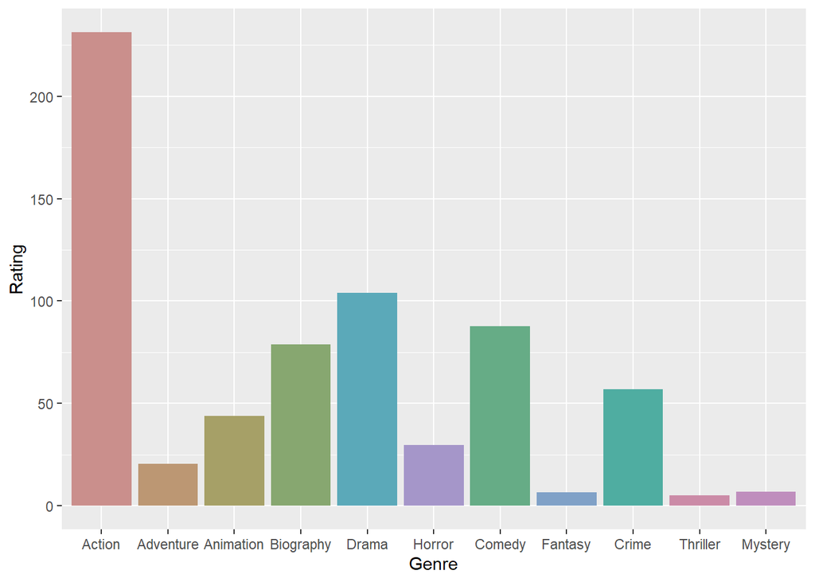

```r
library(ggplot2)
ggplot(movies_df,aes(x=reorder(Genre,-Votes,fun=sum),y=Rating,fill=Genre)) +
  geom_bar(stat='identity') +
  scale_fill_hue(c=40) +
  theme(legend.position="none") +
  xlab("Genre")
```

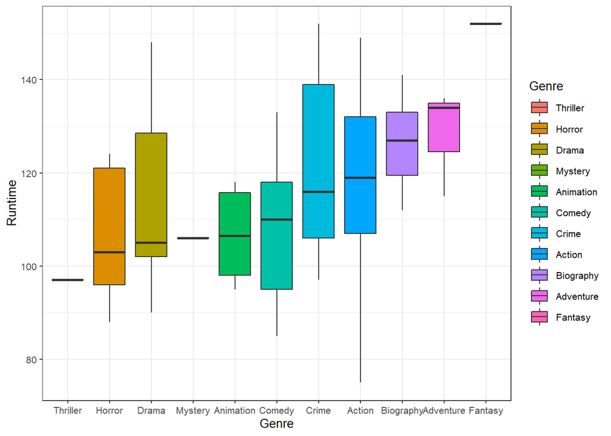

```r
library(ggplot2)
ggplot(movies_df,aes(x=reorder(Genre,Runtime,FUN=median),y=Runtime)) +
  geom_boxplot(aes(fill = reorder(Genre,Runtime,FUN=median))) +
  xlab("Genre") +
  scale_fill_discrete(guide = guide_legend(title = "Genre")) +
  theme_bw(base_size = 10)
```

Now let’s check the frequency distribution of the Rating. We use histogram to plot and the result looks normal, most of the movies has ratings between 6 to 8. And we can consider movies with a score greater or equal to 8 a great movie from many perspectives.

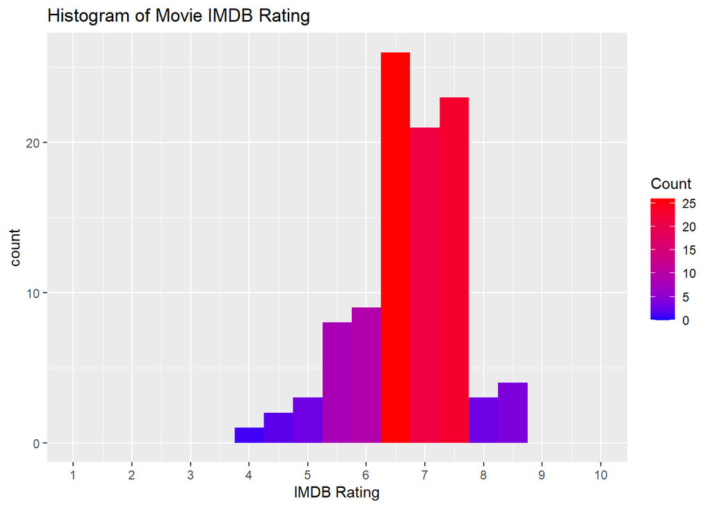

```r
ggplot(movies_df, aes(x = Rating)) +
  geom_histogram(aes(fill = ..count..), binwidth =0.5) +
  scale_x_continuous(name = "IMDB Rating",
                     breaks = seq(0,10),
                     limits=c(1, 10)) +
  ggtitle("Histogram of Movie IMDB Rating") +
  scale_fill_gradient("Count", low = "blue", high = "red")
```

## Analysis

Rating is the most important thing for the public praise of a movie, so after initially look at the data, now we can can construct a model to predict the Rating of a movie based on some variables. Here we use the multi-variable regression model.

```r
movies_df_new = movies_df[which(is.na(movies_df$Metascore)==F & is.na(movies_df$Gross_Earning_in_Mil)==F),]
if(!require("psych"))  {install.packages("psych")}
```

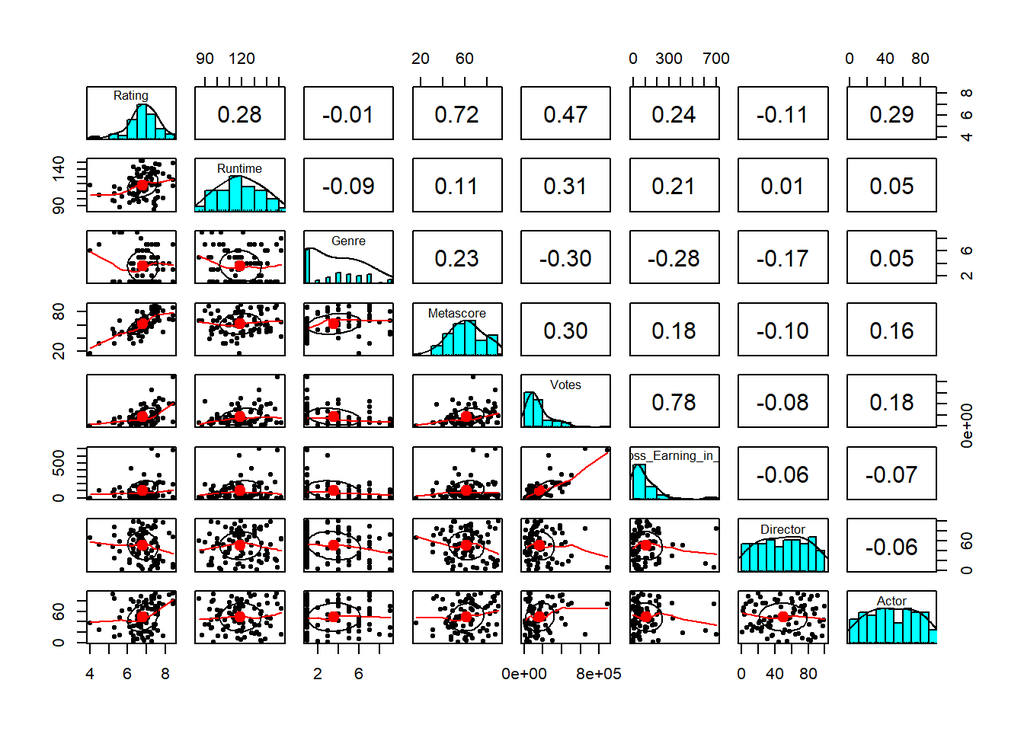

```r
library('psych')
pairs.panels(movies_df_new[c('Rating','Runtime','Genre','Metascore','Votes','Gross_Earning_in_Mil','Director','Actor')])
```

So, We’ll use the genre, metascore, votes,gross as our independent variables and in common sense, these variables are also likely to have some impact on the rating of a movie.We don’t use actor variable because it is a factor variable with too many levels, we don’t use it in fitting a model with only few instances. We now use the `lm()` function to fit a model. We want to find the model with most variables included except variables that are irrelevant, use `summary()` to see the result, it looks good through checking the p-value, the significance is obvious.

```r
lm_model = lm(Rating ~  Genre + Metascore + Votes + Gross_Earning_in_Mil, data = movies_df_new)
summary(lm_model)
```

```
##
## Call:
## lm(formula = Rating ~ Genre + Metascore + Votes + Gross_Earning_in_Mil,
##     data = movies_df_new)
##
## Residuals:
##      Min       1Q   Median       3Q      Max
## -1.22208 -0.24274  0.02386  0.31113  1.32398
##
## Coefficients:
##                        Estimate Std. Error t value Pr(>|t|)
## (Intercept)           4.707e+00  2.257e-01  20.854  < 2e-16 ***
## GenreAdventure       -2.264e-01  2.955e-01  -0.766  0.44608
## GenreAnimation        4.619e-01  2.374e-01   1.945  0.05576 .
## GenreBiography        2.731e-01  1.826e-01   1.495  0.13939
## GenreComedy           2.946e-01  2.035e-01   1.448  0.15221
## GenreCrime            3.494e-02  2.050e-01   0.170  0.86512
## GenreDrama            2.192e-02  1.976e-01   0.111  0.91200
## GenreFantasy         -2.314e-02  4.895e-01  -0.047  0.96243
## GenreHorror          -7.632e-01  2.625e-01  -2.908  0.00487 **
## Metascore             2.870e-02  4.190e-03   6.851 2.33e-09 ***
## Votes                 2.805e-06  6.517e-07   4.305 5.34e-05 ***
## Gross_Earning_in_Mil -1.795e-03  6.900e-04  -2.602  0.01131 *
## ---
## Signif. codes:  0 '***' 0.001 '**' 0.01 '*' 0.05 '.' 0.1 ' ' 1
##
## Residual standard error: 0.475 on 70 degrees of freedom
## Multiple R-squared:  0.7026, Adjusted R-squared:  0.6559
## F-statistic: 15.04 on 11 and 70 DF,  p-value: 1.885e-14
```

Now we can use backwards elimation and the step function to find the best model with AIC value. No variables are eliminated and it seems that the variables we choose initially is appropriate. So oue final model will still use Genre + Metascore + Votes + Gross_Earning_in_Mil to predict the Rating.

```r
backward_model =  step(lm_model, data = movies_df_new, direction = "backward")
```

```
## Start:  AIC=-111.07
## Rating ~ Genre + Metascore + Votes + Gross_Earning_in_Mil
##
##                        Df Sum of Sq    RSS      AIC
## <none>                              15.793 -111.065
## - Gross_Earning_in_Mil  1    1.5273 17.321 -105.496
## - Genre                 8    4.8007 20.594 -105.301
## - Votes                 1    4.1806 19.974  -93.808
## - Metascore             1   10.5887 26.382  -70.991
```

```r
indx = sample(1:nrow(movies_df_new), as.integer(0.8*nrow(movies_df_new)))
#Ramdomize rows, save 80% of data into index
movie_train = movies_df_new[indx,]
movie_test = movies_df_new[-indx,]

lm_fit1 = lm(Rating ~  Genre + Metascore + Votes + Gross_Earning_in_Mil, data = movie_train)
summary(lm_fit1)
```

```
##
## Call:
## lm(formula = Rating ~ Genre + Metascore + Votes + Gross_Earning_in_Mil,
##     data = movie_train)
##
## Residuals:
##      Min       1Q   Median       3Q      Max
## -1.29753 -0.21098  0.04288  0.23400  0.68263
##
## Coefficients:
##                        Estimate Std. Error t value Pr(>|t|)
## (Intercept)           4.719e+00  2.583e-01  18.265  < 2e-16 ***
## GenreAdventure       -1.605e-01  3.415e-01  -0.470   0.6402
## GenreAnimation        5.774e-01  2.226e-01   2.593   0.0123 *
## GenreBiography        3.695e-01  1.869e-01   1.977   0.0532 .
## GenreComedy           4.478e-01  1.974e-01   2.269   0.0274 *
## GenreCrime            1.424e-01  1.988e-01   0.716   0.4771
## GenreDrama            8.886e-02  2.685e-01   0.331   0.7420
## GenreFantasy          1.240e-01  4.512e-01   0.275   0.7845
## GenreHorror          -6.258e-01  2.483e-01  -2.520   0.0148 *
## Metascore             2.574e-02  4.474e-03   5.754 4.45e-07 ***
## Votes                 3.268e-06  6.309e-07   5.180 3.52e-06 ***
## Gross_Earning_in_Mil -1.790e-03  6.550e-04  -2.733   0.0085 **
## ---
## Signif. codes:  0 '***' 0.001 '**' 0.01 '*' 0.05 '.' 0.1 ' ' 1
##
## Residual standard error: 0.4325 on 53 degrees of freedom
## Multiple R-squared:  0.7473, Adjusted R-squared:  0.6949
## F-statistic: 14.25 on 11 and 53 DF,  p-value: 3.16e-12
```

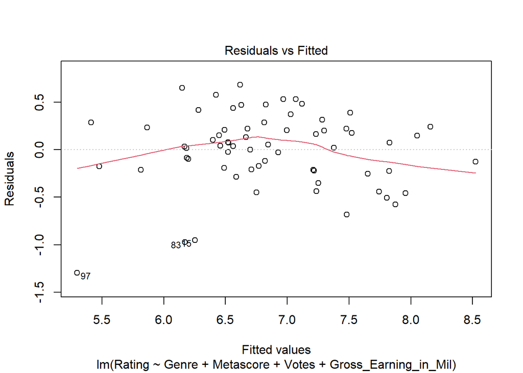

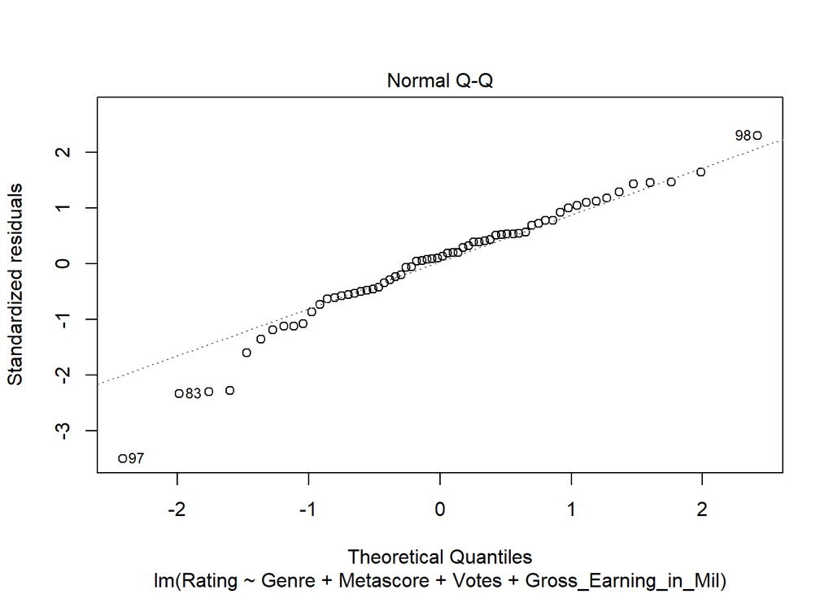

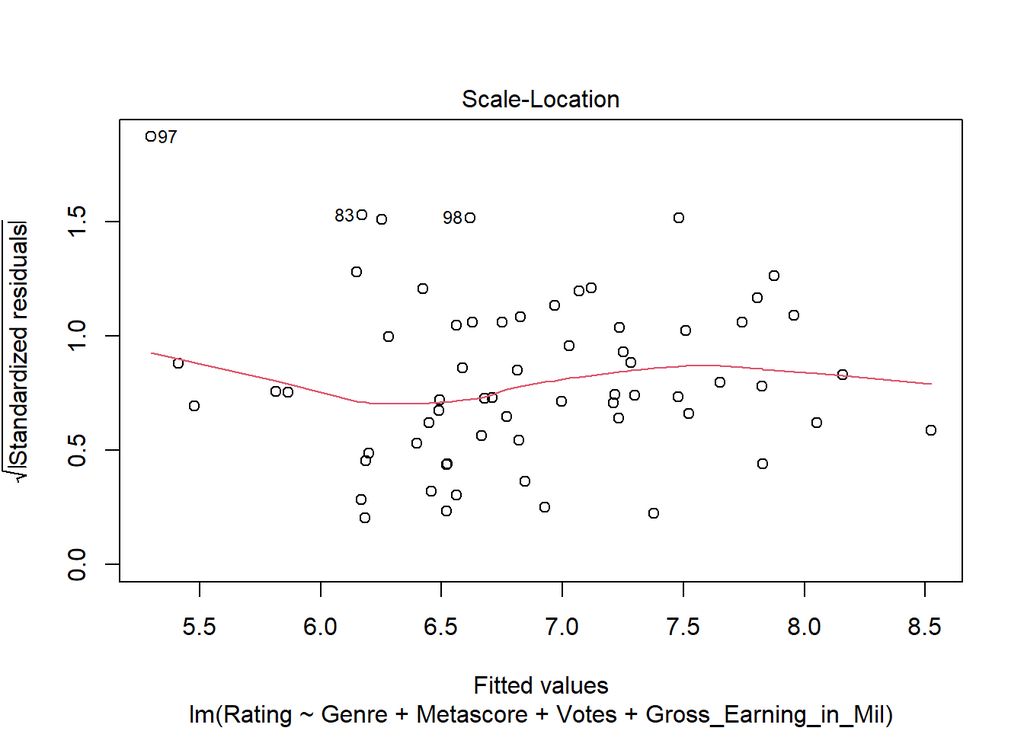

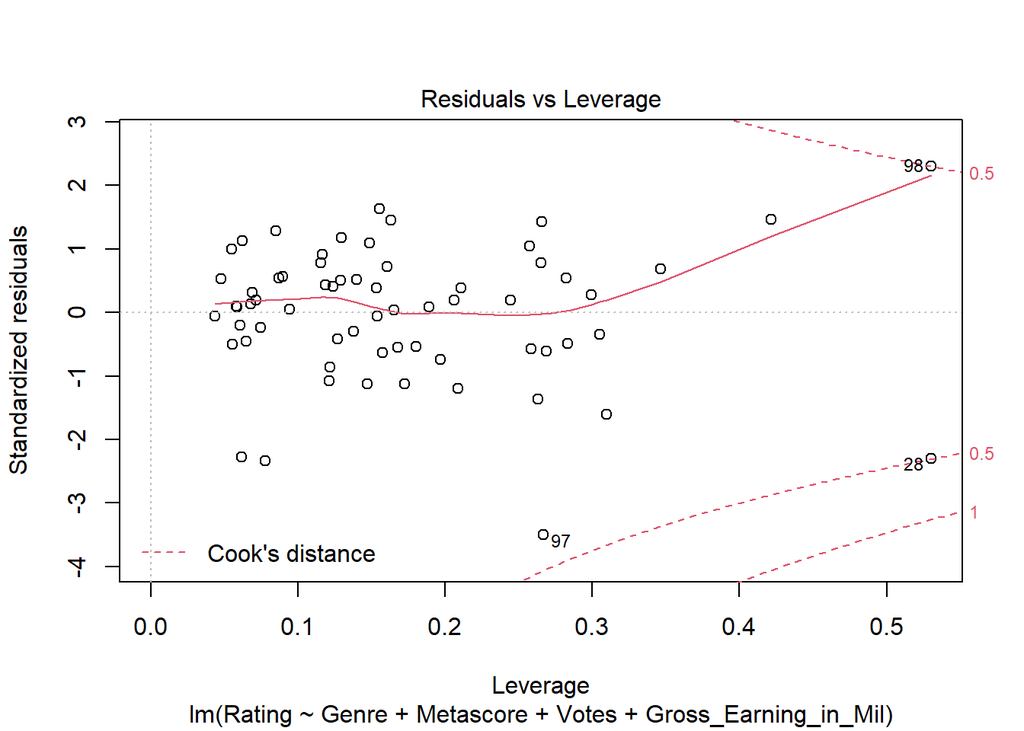

```r
plot(lm_fit1)
```

Then, we can make prediction on the test set

```r
pr = predict.lm(lm_fit1,newdata = data.frame(movie_test),interval = 'confidence')
pr
```

```
##         fit      lwr      upr
## 1  8.023289 7.538927 8.507652
## 26 5.616894 4.972082 6.261707
## 35 7.902653 7.548205 8.257101
## 39 6.157438 5.941884 6.372991
## 40 6.372156 5.696632 7.047681
## 46 6.862591 6.537283 7.187900
## 49 5.671674 5.375346 5.968002
## 53 5.706637 5.415937 5.997337
## 56 6.716824 6.254177 7.179471
## 60 6.965552 6.517535 7.413569
## 61 5.984600 5.737415 6.231786
## 63 6.660501 6.179314 7.141687
## 64 6.219990 6.000815 6.439165
## 73 6.993306 6.771165 7.215448
## 74 6.259398 6.030825 6.487970
## 77 6.294281 6.083872 6.504690
## 85 6.267357 6.025507 6.509208
```

It is also significant to evaluate the model and we mainly focus on 3 things: mean absolute error (MAE), root mean square error (RMSE) and the R squared score (r2). Mean absolute error is an important measure of errors which represents the mean absolute value of the error between the observed value and the true value. The higher the MAE, the lower the accuracy of out model. R squared score is the coefficient determination which measures the amount of variation explained by the least-squares linear regression. For both of these two evaluation standards, the best possible score is 1, and lower values are worse. Root mean square error (RMSE) is the square root of the deviation between the predicted value and the true value divided by the total number of observations n. It is a common method to measure the difference between the predicted value (sample value or population value) and the observed value of a model or estimator. The higher the RMSE, the lower the accuracy of out model.

```r
#MAE
MAE <- function(actual, predicted) {
  mean(abs(actual - predicted))
}
MAE_LR = MAE(pr, movie_test$Rating)
MAE_LR
```

```
## [1] 0.5447178
```

```r
#RMSE
RMSE = function(m, o){
  sqrt(mean((m - o)^2))
}
RMSE_LR = RMSE(movie_test$Rating, pr)
RMSE_LR
```

```
## [1] 0.6857082
```

```r
#R2
R2_LR = summary(lm_fit1)$r.squared
```

Random forest is an algorithm based on classification tree, which can be used for classification and regression. The Stochastic Forest regression model is composed of multiple regression trees, and there is no correlation between each decision tree in the forest. The final output of the model is determined by each decision tree in the forest. In R, we can use `randomForest` model to construct the randomForest model.